# Assignment2

Junyi_Liu

2022-10-14

Firstly,we use Manual 09 to generate gaussian mixture f. The two functions below allow for random number generation and density evaluation for the Gaussian mixture distribution
$$f(x) = (1-\tau) \varphi_{\mu_1,\sigma_1^2}(x) +
\tau\varphi_{\mu_2,\sigma_2^2}(x).$$

```r
rmixnorm <- function(N, mu1, mu2, sigma1, sigma2, tau){
  ind <- I(runif(N) > tau)
  X <- rep(0,N)
  X[ind] <- rnorm(sum(ind), mu1, sigma1)
  X[!ind] <- rnorm(sum(!ind), mu2, sigma2)
  return(X)
}

dmixnorm <- function(x, mu1, mu2, sigma1, sigma2, tau){
  y <- (1-tau)*dnorm(x,mu1,sigma1) + tau*dnorm(x,mu2,sigma2)
  return(y)
}
```

Now we realize the function (with N=100) and get its density function.

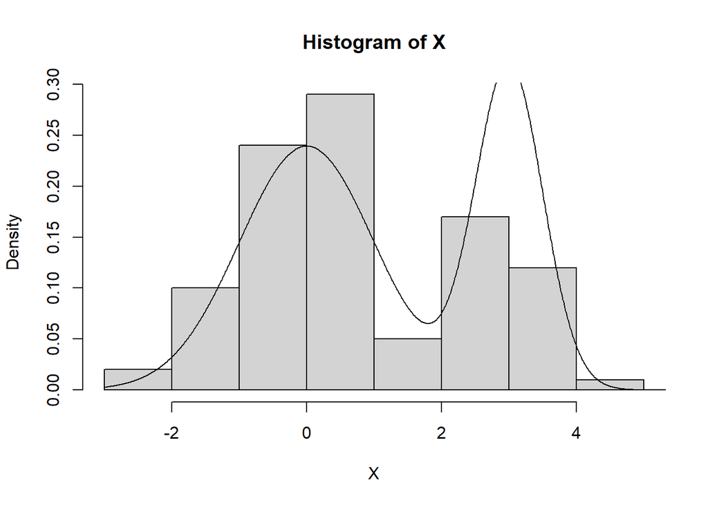

```r
mu1 <- 3
mu2 <- 0
sigma1 <- 0.5
sigma2 <- 1
tau <- 0.6
N <- 100
X <- rmixnorm(N, mu1, mu2, sigma1, sigma2, tau)
x <- seq(-3,6,by=0.01)
fx <- dmixnorm(x, mu1, mu2, sigma1, sigma2, tau)
hist(X,freq=F)
points(x,fx,type="l")
```

Now we perform the density estimation. At the first step, we just run for one time and see how estimation function varies with Bandwidth and Kernel.

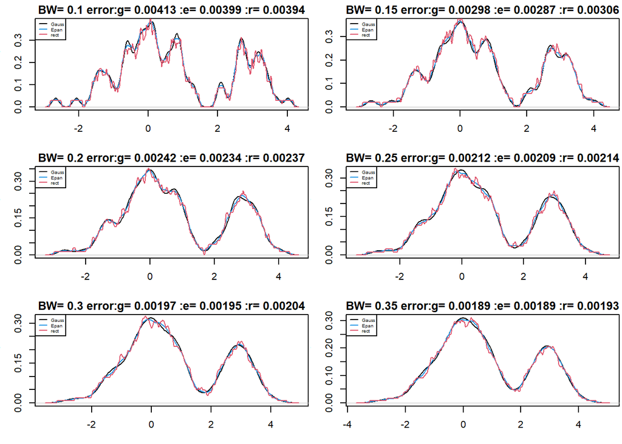

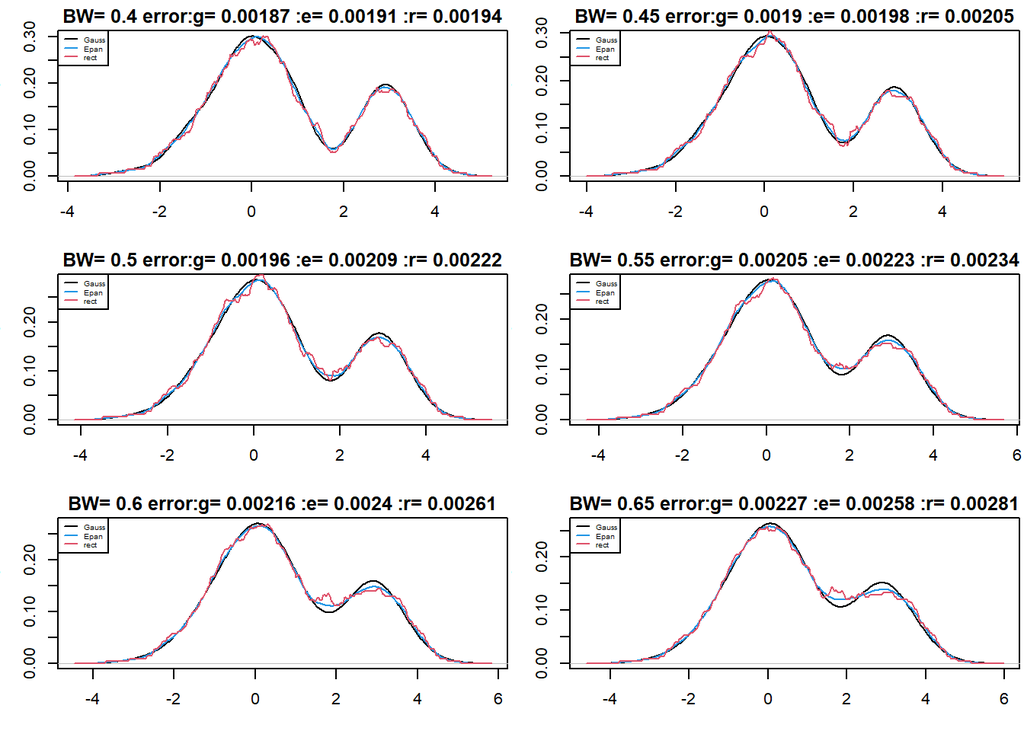

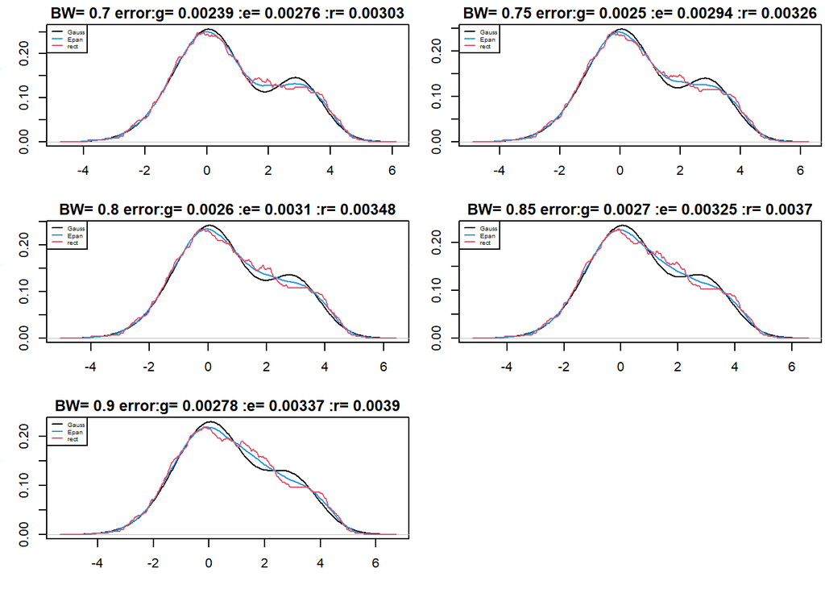

```r
density_my = X
plot_kdes <- function(bw){
  f_hat_g <-density(X,kernel = 'gaussian',bw=bw)
  y_true_g<-dmixnorm(f_hat_g$x, mu1, mu2, sigma1, sigma2, tau)
  y_hat_g <-f_hat_g$y
  error_g <- mean((y_true_g-y_hat_g)^2)

  f_hat_e <-density(X,kernel = 'epanechnikov',bw=bw)
  y_true_e<-dmixnorm(f_hat_e$x, mu1, mu2, sigma1, sigma2, tau)
  y_hat_e <-f_hat_e$y
  error_e <- mean((y_true_e-y_hat_e)^2)

  f_hat_r <-density(X,kernel = 'rectangular',bw=bw)
  y_true_r<-dmixnorm(f_hat_r$x, mu1, mu2, sigma1, sigma2, tau)
  y_hat_r <-f_hat_r$y
  error_r <- mean((y_true_r-y_hat_r)^2)

  plot(density(density_my, kernel="gaussian", bw=bw),
       main=paste("BW=",bw,"error:g=",round(error_g,5),":e=",round(error_e,5),":r=",round(error_r,5)), xlab="time [min]")
  lines(density(density_my, kernel="epanechnikov", bw=bw), col=4)
  lines(density(density_my, kernel="rectangular", bw=bw), col=2)
  legend("topleft", col=c(1, 4, 2), lty=1, cex =0.45, legend=c("Gauss", "Epan", "rect"))
}
par(mfrow=c(3,2), mar = c(3.2, 3, 1.6, 0.2))
for (i in seq(0.1,0.9,by = 0.05)){
plot_kdes(i)
  }
```

```r
density_my = X
calculate <- function(){
error_g <-c()
error_r <-c()
error_e <-c()
for (bw in seq(0.1,0.9,by = 0.05)){
  mse_g <- 0
  mse_e <- 0
  mse_r <- 0
  for (i in c(1:200)){

  f_hat_g <-density(X,kernel = 'gaussian',bw=bw)
  y_true_g<-dmixnorm(f_hat_g$x, mu1, mu2, sigma1, sigma2, tau)
  y_hat_g <-f_hat_g$y
  error_1 <- mean((y_true_g-y_hat_g)^2)
  mse_g = mse_g +error_1

  f_hat_e <-density(X,kernel = 'epanechnikov',bw=bw)
  y_true_e<-dmixnorm(f_hat_e$x, mu1, mu2, sigma1, sigma2, tau)
  y_hat_e <-f_hat_e$y
  error_2 <- mean((y_true_e-y_hat_e)^2)
  mse_e = mse_e +error_2

  f_hat_r <-density(X,kernel = 'rectangular',bw=bw)
  y_true_r<-dmixnorm(f_hat_r$x, mu1, mu2, sigma1, sigma2, tau)
  y_hat_r <-f_hat_r$y
  error_3 <- mean((y_true_r-y_hat_r)^2)
  mse_r = mse_r + error_3
  }
  mse_g = mse_g /200
  error_g<- append(error_g,mse_g)
  mse_e = mse_e/200
  error_e<-append(error_e,mse_e)
  mse_r = mse_r/200
  error_r<-append(error_r,mse_r)
  }
  result = list(error_g,error_e,error_r)
  return (result)
}
```

Here we create a data.frame to receive the MSE results.

```r
a=calculate()
x_ = seq(0.1,0.9,by = 0.05)
MSE_g = unlist(a[1])
MSE_r = unlist(a[2])
MSE_e = unlist(a[3])
MSE<-data.frame(x_,MSE_g,MSE_r,MSE_e);MSE
```

```
##      x_       MSE_g       MSE_r       MSE_e
## 1  0.10 0.004125003 0.003994238 0.003938337
## 2  0.15 0.002976867 0.002865679 0.003059725
## 3  0.20 0.002417488 0.002342440 0.002372243
## 4  0.25 0.002124838 0.002091600 0.002141648
## 5  0.30 0.001965315 0.001952743 0.002039748
## 6  0.35 0.001888324 0.001894544 0.001928260
## 7  0.40 0.001871685 0.001909182 0.001941410
## 8  0.45 0.001901004 0.001978401 0.002048755
## 9  0.50 0.001964883 0.002089085 0.002217144
## 10 0.55 0.002053403 0.002232742 0.002338117
## 11 0.60 0.002157830 0.002399114 0.002607057
## 12 0.65 0.002270597 0.002577751 0.002807405
## 13 0.70 0.002385245 0.002760269 0.003026897
## 14 0.75 0.002496609 0.002936143 0.003255003
## 15 0.80 0.002600672 0.003099735 0.003484515
## 16 0.85 0.002695167 0.003245486 0.003703091
## 17 0.90 0.002778232 0.003369875 0.003899973
```

Plot to see MSE of function with different Kernel and Bandwidth.

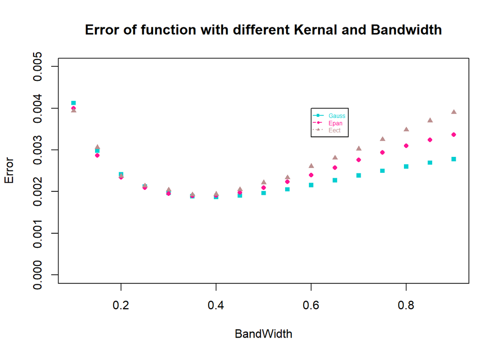

```r
plot(MSE_g~x_,pch=15,cex=0.8,col="DarkTurquoise",ylab="Error",xlab = "BandWidth",ylim = c(0,0.005),main="Error of function with different Kernal and Bandwidth")
points(x_,MSE_r,pch=16,col="DeepPink",cex=0.8)
points(x_,MSE_e,pch=17,col="RosyBrown",cex=0.8)
legend(0.6,0.004,c("Gauss","Epan","Eect"),cex =0.5,col=c("DarkTurquoise","DeepPink","RosyBrown"),text.col=c("DarkTurquoise","DeepPink","RosyBrown"),pch=c(15,16,17),lty=c(1,2,3))
```